# Practical_machine_learning_peer_graded_assignment

Vikash Patel

11/06/2020

```r
#Loading the required libraries
library(knitr)
library(caret)
library(rpart)
```

```r
library(rpart.plot)
library(rattle)
library(corrplot)
library(caTools)
```

I have called all the required libraries that I will need for my classification assignment.

```r
#For reproducibilty
set.seed(251996)
```

For reproducibility of result,I have set the see at 251996

```r
#Getting the url of training and test dataset
train_url="http://d396qusza40orc.cloudfront.net/predmachlearn/pml-training.csv"
test_url="http://d396qusza40orc.cloudfront.net/predmachlearn/pml-testing.csv"
#downloading into csv file
training_set =read.csv(url(train_url))
testing_set = read.csv(url(test_url))
attach(training_set)
```

I have loaded the training and testing dataset from the desired url location.And then converted into a csv file so that R can perform its application. I have also used attach(),so that I can refer to the the features of dataset with their name only.

```r
#Creating a partition in training set
sample=sample.split(training_set,SplitRatio = 0.75)
train_set=subset(training_set,sample==T)
test_set=subset(training_set,sample==F)
dim(train_set)
```

```
## [1] 14713   160
```

```r
dim(test_set)
```

```
## [1] 4909  160
```

I have used library caTools to create a partition in the training dataset.Our new train_set has 14713 rows and 160 coloumn.While,test_set has 4909 rows and 160 columns.

```r
#pre-processing of data
NZV=nearZeroVar(train_set)
train_set=train_set[,-NZV]
test_set=test_set[,-NZV]
#Removing the variables which relates to the identity of individual including ID
train_set=train_set[,-(1:5)]
test_set=test_set[,-c(1:5)]
str(train_set)
```

```
## 'data.frame':    14713 obs. of  97 variables:
##  $ num_window              : int  11 11 12 12 12 12 12 12 12 12 ...
##  $ roll_belt               : num  1.41 1.41 1.48 1.48 1.45 1.42 1.45 1.42 1.48 1.51 ...
##  $ pitch_belt              : num  8.07 8.07 8.05 8.07 8.06 8.13 8.18 8.2 8.15 8.12 ...
##  $ yaw_belt                : num  -94.4 -94.4 -94.4 -94.4 -94.4 -94.4 -94.4 -94.4 -94.4 -94.4 ...
##  $ total_accel_belt        : int  3 3 3 3 3 3 3 3 3 3 ...
##  $ max_roll_belt           : num  NA NA NA NA NA NA NA NA NA NA ...
##  $ max_picth_belt          : int  NA NA NA NA NA NA NA NA NA NA ...
##  $ min_roll_belt           : num  NA NA NA NA NA NA NA NA NA NA ...
##  $ min_pitch_belt          : int  NA NA NA NA NA NA NA NA NA NA ...
##  $ amplitude_roll_belt     : num  NA NA NA NA NA NA NA NA NA NA ...
##  $ amplitude_pitch_belt    : int  NA NA NA NA NA NA NA NA NA NA ...
##  $ var_total_accel_belt    : num  NA NA NA NA NA NA NA NA NA NA ...
##  $ avg_roll_belt           : num  NA NA NA NA NA NA NA NA NA NA ...
##  $ stddev_roll_belt        : num  NA NA NA NA NA NA NA NA NA NA ...
```

[output cut: 83 more lines]

```r
#Many vairables only have NA in it,so we will remove those variables
OnlyNA= sapply(train_set, function(x) mean(is.na(x))) > 0.95
train_set =train_set[, OnlyNA==FALSE]
test_set= test_set[, OnlyNA==FALSE]
str(train_set)
```

```
## 'data.frame':    14713 obs. of  54 variables:
##  $ num_window          : int  11 11 12 12 12 12 12 12 12 12 ...
##  $ roll_belt           : num  1.41 1.41 1.48 1.48 1.45 1.42 1.45 1.42 1.48 1.51 ...
##  $ pitch_belt          : num  8.07 8.07 8.05 8.07 8.06 8.13 8.18 8.2 8.15 8.12 ...
##  $ yaw_belt            : num  -94.4 -94.4 -94.4 -94.4 -94.4 -94.4 -94.4 -94.4 -94.4 -94.4 ...
##  $ total_accel_belt    : int  3 3 3 3 3 3 3 3 3 3 ...
##  $ gyros_belt_x        : num  0 0.02 0.02 0.02 0.02 0.02 0.03 0.02 0 0 ...
##  $ gyros_belt_y        : num  0 0 0 0.02 0 0 0 0 0 0 ...
##  $ gyros_belt_z        : num  -0.02 -0.02 -0.03 -0.02 -0.02 -0.02 -0.02 0 0 -0.02 ...
##  $ accel_belt_x        : int  -21 -22 -22 -21 -21 -22 -21 -22 -21 -21 ...
##  $ accel_belt_y        : int  4 4 3 2 4 4 2 4 4 4 ...
##  $ accel_belt_z        : int  22 22 21 24 21 21 23 21 23 22 ...
##  $ magnet_belt_x       : int  -3 -7 -6 -6 0 -2 -5 -3 0 -6 ...
##  $ magnet_belt_y       : int  599 608 604 600 603 603 596 606 592 598 ...
##  $ magnet_belt_z       : int  -313 -311 -310 -302 -312 -313 -317 -309 -305 -317 ...
```

[output cut: 40 more lines]

```r
dim(train_set)
```

```
## [1] 14713    54
```

Given data is raw and has lots of messiness in it.So, I took few steps to clean it. 1)Removed all the variables which have zero or near zero variance in it.Doing so,I removed 58 variables from our dataset. 2.)There are few variables which contain personal details of each individual and does not give any meaningful insight to our model and anaylsis.So,I removed first variables. 3.)After performing above two steps,I found out that lots of variables have lots of NA values in their column.So,I removed all the variables in which more than 95% of the data contain NA.

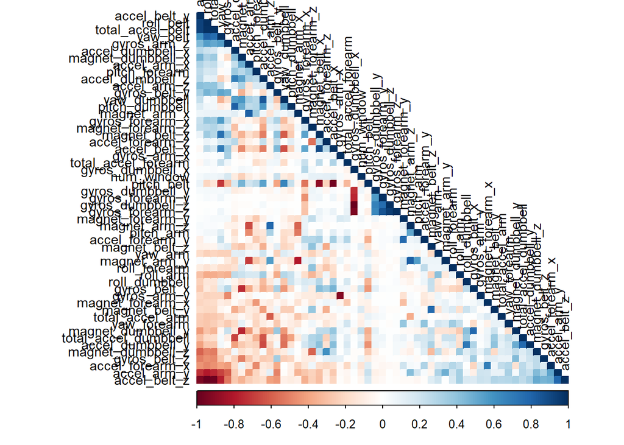

```r
#I look for correlation between our features using corrplot()
cordata=cor(train_set[,-54])
corrplot(cordata,order = "FPC",method = "color",
         type = "lower",tl.cex = 0.9,tl.col = rgb(0,0,0))
```

The cell with darkner color reprsent high correlation.We can see that only few variables have high correlation. The model I am going to use is,is a tree-based model.So,high correlation does not affect the accuracy of our model.

```r
#I will start with decision tree
set.seed(251996)
Decision_tree=train(classe~.,data = train_set,method="rpart")
```

I have used train() funtion from the Caret package for my decision tree model.

[figure not shown]

```r
#So,now we have planted an individual tree, we will use fancy plot from
fancyRpartPlot(Decision_tree$finalModel,main = "Decison Tree",
               type = 2)
```

So,with rpart ,I have grown a tree on the given dataset.

```r
#Prediction on test data
pred_DT=predict(Decision_tree,newdata = test_set)
confusionMatrix(pred_DT,test_set$classe)
```

```
## Confusion Matrix and Statistics
##
##           Reference
## Prediction    A    B    C    D    E
##          A 1262  414  421  361  131
##          B   22  309   27  140  122
##          C  108  230  403  306  241
##          D    0    0    0    0    0
##          E    4    0    0    0  408
##
## Overall Statistics
##
##                Accuracy : 0.4852
##                  95% CI : (0.4712, 0.4993)
##     No Information Rate : 0.2844
##     P-Value [Acc > NIR] : < 2.2e-16
##
##                   Kappa : 0.3267
##
##  Mcnemar's Test P-Value : NA
##
## Statistics by Class:
##
##                      Class: A Class: B Class: C Class: D Class: E
## Sensitivity            0.9040  0.32424  0.47356   0.0000  0.45233
## Specificity            0.6223  0.92139  0.78191   1.0000  0.99900
## Pos Pred Value         0.4874  0.49839  0.31289      NaN  0.99029
## Neg Pred Value         0.9422  0.84985  0.87628   0.8356  0.89015
## Prevalence             0.2844  0.19413  0.17336   0.1644  0.18374
## Detection Rate         0.2571  0.06295  0.08209   0.0000  0.08311
## Detection Prevalence   0.5274  0.12630  0.26238   0.0000  0.08393
## Balanced Accuracy      0.7631  0.62281  0.62774   0.5000  0.72566
```

I have used the decision tree model to predict the classe of the test data that I created. Overall accuracy is just 0.4852.Which is totally unsatisfactory.Even the upper confidence interval dones not cross the the 50% threshold. Kappa statistics,which calculates the agreement is also very low,at 0.3267. If,we go by class statistics.Predition for few classes has been good while the prediction for some classes are disastrous. This was a result by a single tree. Now I will grow a forest by using Random Forest algorithm.Which used bootstrapping aggregated method to calculate the prediction of classes.

```r
set.seed(251996)
RF_control=trainControl(method = "cv",number = 4,verboseIter = F)
RF_model=train(classe~.,data = train_set,method="rf",
               trControl=RF_control)
varImp(RF_model)
```

```
## rf variable importance
##
##   only 20 most important variables shown (out of 53)
##
##                      Overall
## num_window           100.000
## roll_belt             64.264
## pitch_forearm         38.699
## magnet_dumbbell_z     30.211
## yaw_belt              29.475
## magnet_dumbbell_y     29.272
## pitch_belt            27.617
## roll_forearm          25.956
## accel_dumbbell_y      13.625
## magnet_dumbbell_x     10.459
## accel_forearm_x       10.152
## accel_belt_z           9.607
## roll_dumbbell          9.536
## total_accel_dumbbell   9.165
## accel_dumbbell_z       7.626
## magnet_belt_y          7.487
## magnet_forearm_z       7.384
## magnet_belt_z          6.668
## magnet_belt_x          6.136
## roll_arm               5.033
```

```r
#Predition on test data using random forest model
pred_RF=predict(RF_model,newdata = test_set)
confusionMatrix(pred_RF,test_set$classe)
```

```
## Confusion Matrix and Statistics
##
##           Reference
## Prediction    A    B    C    D    E
##          A 1396    1    0    0    0
##          B    0  951    1    0    2
##          C    0    0  850    2    0
##          D    0    1    0  805    2
##          E    0    0    0    0  898
##
## Overall Statistics
##
##                Accuracy : 0.9982
##                  95% CI : (0.9965, 0.9992)
##     No Information Rate : 0.2844
##     P-Value [Acc > NIR] : < 2.2e-16
##
##                   Kappa : 0.9977
##
##  Mcnemar's Test P-Value : NA
##
## Statistics by Class:
##
##                      Class: A Class: B Class: C Class: D Class: E
## Sensitivity            1.0000   0.9979   0.9988   0.9975   0.9956
## Specificity            0.9997   0.9992   0.9995   0.9993   1.0000
## Pos Pred Value         0.9993   0.9969   0.9977   0.9963   1.0000
## Neg Pred Value         1.0000   0.9995   0.9998   0.9995   0.9990
## Prevalence             0.2844   0.1941   0.1734   0.1644   0.1837
## Detection Rate         0.2844   0.1937   0.1732   0.1640   0.1829
## Detection Prevalence   0.2846   0.1943   0.1736   0.1646   0.1829
## Balanced Accuracy      0.9999   0.9986   0.9992   0.9984   0.9978
```

We build the random forest on our training set.Now,I have used the test_set to measure the performance of RF_model. I must say,Random Forest model has performed magnificently well here.The overall accuracy is 0.9982 and the kappa statistics is 0.9977. Our upper and lower confidence interval is in 0.99s only.Which suggest that our model has very low variance in it.Which is a good news.

```r
#Using the model to predict the classe variable in the testing data which has 20 rows.
predictTest=predict(RF_model,newdata = testing_set)
predictTest
```

```
##  [1] B A B A A E D B A A B C B A E E A B B B
## Levels: A B C D E
```

I used tree based model for this project.Decision Tree does not worked well this dataset.So,I used the Random Forest model which gave tremendous result.